# Not just R-spatial: sustaining open source geospatial software stacks

Roger Bivand

2 September 2019, 11:00-13:00, Room 401

### Copyright

The presentation files are on github at: (https://rsbivand.github.io/geostat19_talk)

## History of R and its data structures

### Sources

- [Rasmus Bååth](http://www.sumsar.net/blog/2014/11/tidbits-from-books-that-defined-s-and-r/) has a useful blog piece on R’s antecedents in the S language
- Something similar is present in the second chapter of Chambers (2016), from the viewpoint of one of those responsible for the development of the S language
- In addition to S, we need to take [SICP and Scheme](http://sarabander.github.io/sicp/html/index.xhtml) into account (Abelson and Sussman 1996), as described by Ihaka and Gentleman (1996) and Wickham (2014)
- Finally, LispStat and its creators have played and continue to play a major role in developing R (Tierney 1990, 1996, 2005)

### Early R was Scheme via SICP

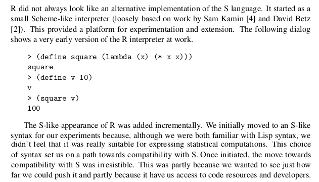

Ross Ihaka’s description

([JSM talk](https://www.stat.auckland.ac.nz/%7Eihaka/downloads/JSM-2010.pdf))

### From S to R: Brown Books

Becker and Chambers (1984): S: An Interactive Environment for Data Analysis and Graphics, A.K.A. the Brown Book

Becker and Chambers (1985): Extending the S System

[figure not shown]

### From S to R: Blue and White Books

Becker, Chambers and Wilks (1988): The New S Language: A Programming Environment for Data Analysis and Graphics, A.K.A. the Blue Book.

Chambers and Hastie (1992): Statistical Models in S, A.K.A. the White Book.

[figure not shown]

Blue and White Books

### From S to R: Green Book

Chambers (1998): Programming with Data: A Guide to the S Language, A.K.A. the Green Book.

Venables and Ripley (2000): S Programming

[figure not shown]

### S2 to S3 to S4

- The S2 system was described in the Brown Book, S3 in the Blue Book and completed in the White Book, finally S4 in the Green Book
- The big advance from S2 to S3 was that users could write functions; that data.frame objects were defined; that formula objects were defined; and that S3 classes and method dispatch appeared
- S4 brought connections and formal S4 classes, the latter seen in R in the **methods** package ([still controversial](https://stat.ethz.ch/pipermail/r-devel/2017-December/075304.html))
- S-PLUS was/is the commercial implementation of S and its releases drove S3 and S4 changes

### S, Bell Labs, S-PLUS

- S was a Bell Labs innovation, like Unix, C, C++, and many interpreted languages (like AWK); many of these share key understandings
- Now owned by Nokia, previously Alcatel-Lucent, Lucent, and AT&T
- Why would a telecoms major (AT&T) pay for fundamental research in computer science and data analysis (not to sell or market other products better)?
- Some Green Book examples are for quality control of telecoms components

### S-PLUS and R

- S-PLUS was quickly adopted for teaching and research, and with S3, provided extensibility in the form of libraries
- Most links have died by now, but see this [FAQ}](http://ftp.uni-bayreuth.de/math/statlib/S/FAQ) for a flavour - there was a lively community of applied statisticians during the 1990s
- S built on a long tradition of documentation through examples, with use cases and data sets taken from the applied statistical literature; this let users compare output with methods descriptions
- … so we get to R

### and what about LispStat?

- Luke Tierney was in R core in 1997, and has continued to exert clear influence over development
- Because R uses a Scheme engine, similar to Lisp, under the hood, his insight into issues like the garbage collector, namespaces, byte-compilation, serialization, parallelization, and now [ALTREP](http://blog.revolutionanalytics.com/2018/04/r-350.html) has been crucial ([see also the proposal by Luke Tierney, Gabe Becker and Tomas Kalibera}](https://svn.r-project.org/R/branches/ALTREP/ALTREP.html))
- Many of these issues involve the defensive copy on possible change policy involved in lazy evaluation, which may lead to multiple redundant copies of data being present in memory
- Luke Tierney and Brian Ripley have fought hard to let R load fast, something that is crucial to ease the use of R on multicore systems or inside databases

## R spatial and R-sig-geo

### Antecedents (among others)

- The [AI-GEOSTATS](https://wiki.52north.org/AI_GEOSTATS/ForumHistory) listserve/mailing list was started by Gregoire Dubois in 1995; AI was from Arc/Info
- GRASS accepted code contributions, then kept in `src.contrib` and `src.garden` and GRASS mailing lists were active (the archives seem to have been lost in moving from minordomo to mailman in 2001)
- Bao et al. (2000) describe S-PLUS links to GRASS and ArcView; the module for spatial statistics was also from the mid-1990’s
- `MASS` included S and compiled code for kriging, trend surfaces and point pattern analysis, `splancs` provided point pattern analysis

### Albrecht Gebhardt

- Much of the porting of S code to R for spatial statistics was begun by Albrecht Gebhardt
- The CRAN archives show `tripack` and `akima` - both with ACM licenses - from August 1998; `ash` and `sgeostat` followed in April 1999
- The date for the MASS `spatial` package is unknown because it was bundled in the `VR` metapackage subsequently split into `spatial`, `MASS`, `nnet` and `class`
- In the earliest period, CRAN admins helped practically with porting

### Barry Rowlingson

- Rowlingson and Diggle (1993) describes the S-PLUS version of `splancs` for point pattern analysis
- I’d contacted Barry in 1997 but only moved forward with porting `splancs` as R’s ability to load shared objects advanced
- In September 1998, I wrote to him:

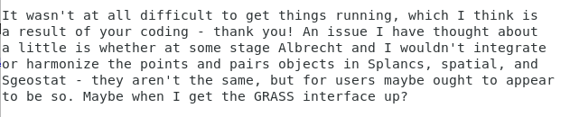

- The earliest `splancs` in the CRAN archive is from November 2000

### 1998 ERSA talk

- Albrecht and I were teaching spatial data analysis using R and code that would go into CRAN packages (I still have the package I wrote, and the exams)
- In 1998, the ERSA (European Regional Science Association) meeting was in Vienna, and we gave a talk subsequently published in Bivand and Gebhardt (2000)
- We covered R, point pattern analysis, geostatistics, ESDA and spatial econometrics

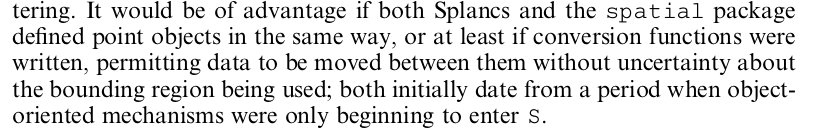

### GEOCOMP 2000

- Markus Neteler and I were in touch too, as I’d been trying to interface R and GRASS (R. Bivand 2000)

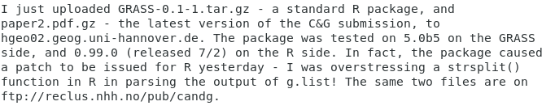

- The first `GRASS` package in the CRAN archive is from November 2000
- Before that, we’d presented at GeoComputation 2000 in Chatham Bivand and Neteler (2000)

### Nicholas Lewin-Koh

- Nicholas Lewin-Koh posted on the R list (subsequently split between R-help and R-devel) in September 2000, asking about coding the reading of ESRI shapefiles
- He made a number of key contributions which ended up in `spweights` - currently part of `spdep` - and what became `maptools`
- He wrote the first vector representation based on the shapefile import format, and I should be blamed for subsequent fumbling implementations in `maptools`

### DSC 2001

- From interaction with Kurt Hornik, Ross Ihaka and Brian Ripley on the R list during late 2000, contacts widened, including Tim Keitt (`rgdal`)
- I ended up presenting at the DSC meeting in Vienna in March 2001, getting to meet many R core members, developers and CRAN admins

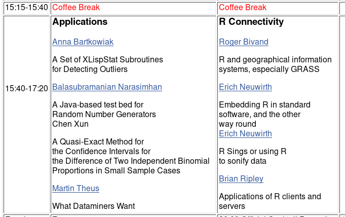

### Luc Anselin

- Further contacts came from a CSISS workshop organised by Luc Anselin in May 2002 in Santa Barbara, including Konstantin Krivoruchko (ESRI) and Gilberto Câmara (INPE)
- My talk eventually appeared as Bivand (2006), but the contacts were more useful
- Visiting the INPE earth observation lab and presenting at a conference in December 2002 provided further ideas and links to TerraLib
- Luc himself contributed code to `spdep` and continues be very supportive
- I did a further piece for the ERSA 2002 conference in Dortmund (Bivand 2002)

### Getting to R spatial

- The DSC meeting in March 2003 was also being planned for Vienna, and I’d talked about it with Kurt Hornik when he gave a keynote at the GRASS meeting in Trento in September 2002
- I met Virgilio Gómez-Rubio at the GRASS meeting among many others and talked about `DCluster` and `RArcInfo`

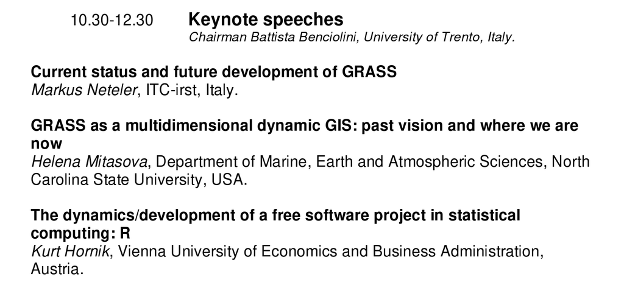

### Planning for R spatial

- In mid November I started emailing contacts to invite sumbissions for a spatial statistics session at DSC, and a workshop at which we could discuss working together
- Of the replies, far more would have liked to attend than were able to (Pebesma 2004; Gómez-Rubio, Ferrándiz-Ferragud, and López-Quílez 2005; Gómez-Rubio and López-Quílez 2005)

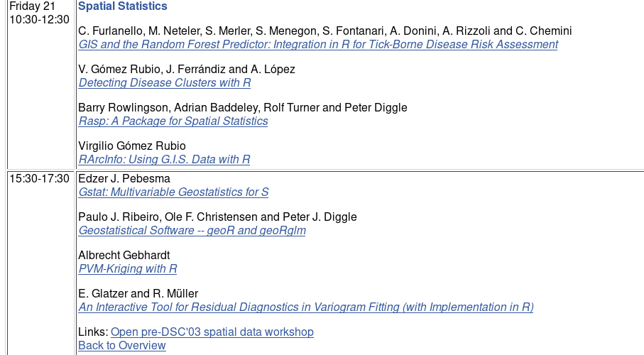

### Workshop

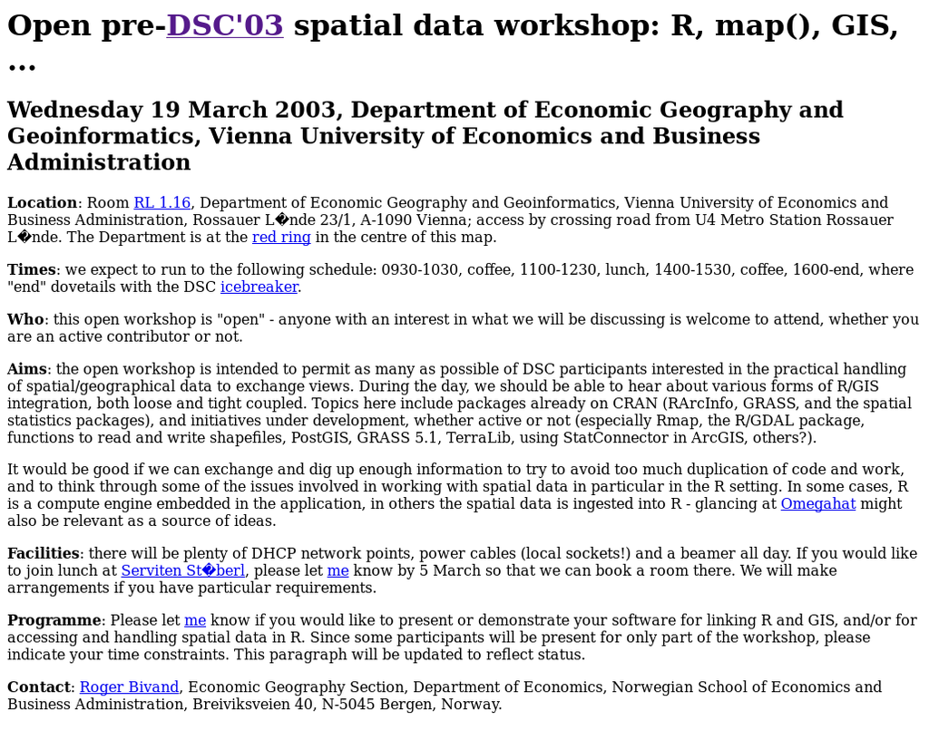

### Edzer Pebesma

Correspondence developed quickly (21 November)

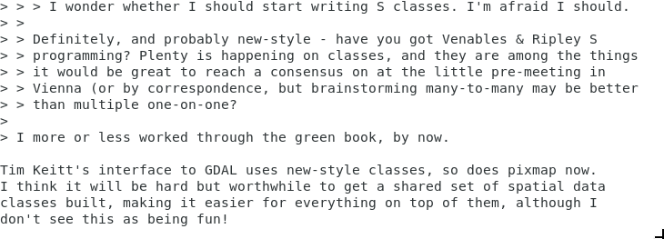

### Classes and Nicholas Lewin-Koh

Contribution even though he couldn’t get to Vienna:

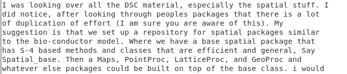

### E-mail traffic: PROJ4

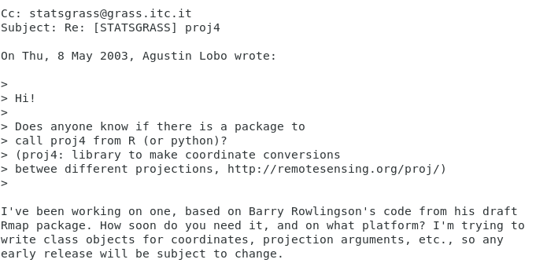

### R-sig-geo

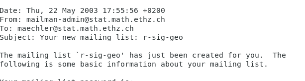

### StatGIS meeting 2003

- Albrecht Gebhardt was a local organiser for a meeting at which many of those at the DSC workshop met in October 2003

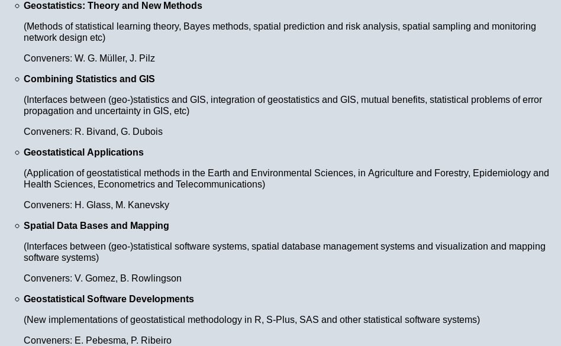

### useR! 2004

- R News class description: (Pebesma and Bivand 2005)

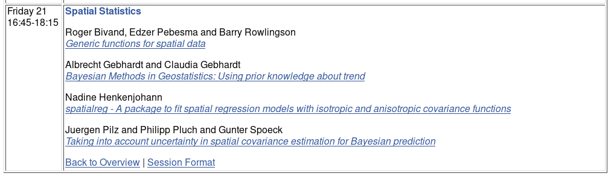

### CRAN arrivals

- `fields` and `geoR` in mid-2001, `spatstat` in early 2002
- `gstat` in February 2003, `maptools` in August 2003, `rgdal` in November 2003
- `sp` in April 2005 (after a workshop in Lancaster November 2004 and before one in Valencia May 2005)
- `classInt` in March 2006, `spgrass6` in August 2006

### useR! 2006

[figure not shown]

### useR! 2006

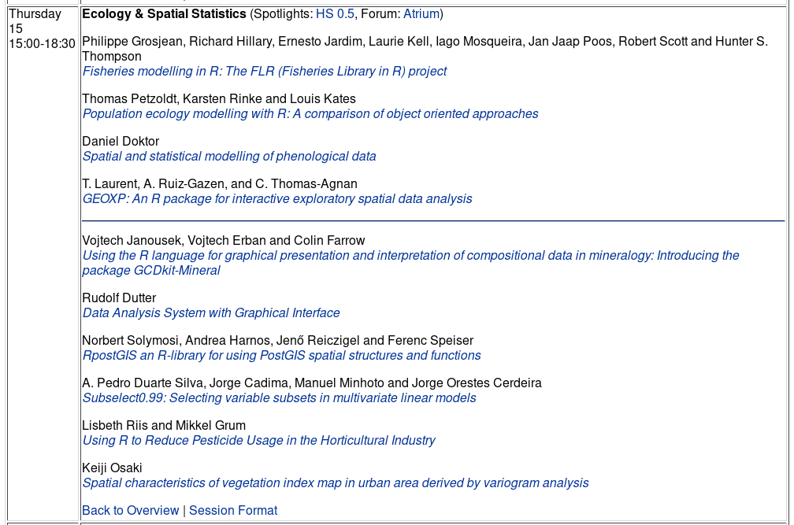

## Open Source Geospatial software stacks

### Software component stacks

- A chapter written in 2011 and published three years later has an overview (Bivand 2014)
- Before discussing software component stacks for GC, we should acknowledge the importance of open standards for geospatial data interchange
- Kralidis (2008) points out the importance of concepts such as that of spatial data infrastructure, whether established within national jurisdictions, within supranational jurisdictions, or by international standards organisations
- A fuller coverage of the relationships between spatial data infrastructures and free and open source geospatial software is given by Steiniger and Hunter (2012)
- Kralidis also helpfully distinguishes between formal, de facto, and ad hoc standards, which provide the flexibility needed to move ahead somewhat faster than standards committees are usually able to do

### Component stacks

- Software components appear to have been defined first by McIlroy (1969), as interchangeable subassemblies by analogy with mass production manufacturing
- The software component stack has been a core concept of programming at least since the publication of Kernighan and Plauger(1976), systematising the experience of Bell Labs computer scientists
- Some of the lessons are made clear in programming itself (Kernighan and Pike 1999), while others affect how one may “glue” small utility functions together in an interactive and/or scripting language (Kernighan and Pike 1984)
- Consequently, a software component stack can be taken as sequence of component programs that are used together to achieve a common goal

### Component stacks

- Using stacks of components becomes attractive when task objectives can more easily be met by using components developed by others than by developing them independently
- When the costs of keeping a stack working exceed those of rewriting, the stack may fail, but this is seldom the case
- Open source software developers often advertise application programming interfaces (API), with an implicit promise that other downstream developers using the API will be less subject to incompatible changes
- It is then vital that changes in these underlying components do not change the way that dependent components function, unless their earlier behaviour had been in error

### Dependency challenges

- As already noted, developers wishing to integrate software components in stacks must pay careful attention to the versioning of the components, and to the impacts of upstream changes on downstream components
- The terms upstream and downstream refer to the ordering of the components, with data flowing from upstream to downstream components
- If the specification of an upstream component changes, those following it will need to be modified
- If the changes are forced by real bugs being fixed, or security holes being blocked, downstream components must react in appropriate ways

### Dependency challenges

- However, some changes occur for other reasons, such as code cleaning, reimplementation, or the resolution of licence issues in otherwise functioning code
- In most cases, upstream developers then attempt to reduce changes in their interfaces with downstream components to an unavoidable minimum
- Open source projects are typically most constrained with respect to developer time for maintenance, including the revision of functioning code to accommodate upstream changes that may not improve downstream performance
- A particularly troublesome issue for dynamically linked software components in relatively long-running applications is that of thread safety

### Open source geospatial projects

- The Open Source Geospatial Foundation was brought into being in 2006 as a successor to the Mapserver Foundation, itself created the year before
- In addition to providing a shared infrastructure and procedural framework for web mapping, desktop application and geospatial library projects, OSGeo aims to promote open source geospatial software use and development, including use integrated with proprietary software
- McIhagga (2008) discusses some of the ways in which communities of practice have developed, with particular reference to web mapping, and in his description, the open source web mapping “ecology”
- The Geospatial Data Abstraction Library is a crucial part of the upstream geospatial library infrastructure

### Open source geospatial projects

- One of the most important components required by geospatial applications is the provision of robust and clear representations of coordinate reference systems
- Because GEOS uses OGC SFS specifications for geometries, it does not “build” topologies in the classical GIS arc-node understanding
- GRASS (Geographic Resources Analysis Support System) was already twenty years old when the GRASS developers collaborated in founding OSGeo, and they have been playing an important role in the broader OSGeo movement (Neteler et al. 2008); many of the more recent developments in GRASS are covered by Neteler et al. (n.d.)

## Spatial reference systems

Spatial data typically combine position data in 2D (or 3D), attribute data and metadata related to the position data. Much spatial data could be called map data or GIS data. We collect and handle much more position data since global navigation satellite system (GNSS) like GPS came on stream 20 years ago, earth observation satellites have been providing data for longer.

```r
library(osmdata)
library(sf)
bbox <- opq(bbox = 'bergen norway')
byb0 <- osmdata_sf(add_osm_feature(bbox, key = 'railway',
  value = 'light_rail'))$osm_lines
tram <- osmdata_sf(add_osm_feature(bbox, key = 'railway',
  value = 'tram'))$osm_lines
byb1 <- tram[!is.na(tram$name),]
o <- intersect(names(byb0), names(byb1))
byb <- rbind(byb0[,o], byb1[,o])
```

### Baseline WKT and PROJ4

Spatial reference systems define how the geoid is viewed (prime meridian, ellipsoid, datum), and, if projected to the plane, where we are (central longitude, latitude, offsets, etc.). Projection (no datum change) and transformation are possible using PROJ and its legacy `proj_api.h` interface directly (`rgdal::spTransform()` and `lwgeom::st_transform_proj()`), or through GDAL (`sf::st_transform()`).

```r
(WKT <- st_crs(byb))
```

```
## Coordinate Reference System:
##   EPSG: 4326
##   proj4string: "+proj=longlat +datum=WGS84 +no_defs"
```

```r
strwrap(gsub(",", ", ", st_as_text(WKT)))
```

```
## [1] "GEOGCS[\"unknown\", DATUM[\"WGS_1984\", SPHEROID[\"WGS 84\", 6378137,"
## [2] "298.257223563, AUTHORITY[\"EPSG\", \"7030\"]], AUTHORITY[\"EPSG\","
## [3] "\"6326\"]], PRIMEM[\"Greenwich\", 0, AUTHORITY[\"EPSG\", \"8901\"]],"
## [4] "UNIT[\"degree\", 0.0174532925199433, AUTHORITY[\"EPSG\", \"9122\"]],"
## [5] "AXIS[\"Longitude\", EAST], AXIS[\"Latitude\", NORTH]]"
```

```r
byb_utm <- st_transform(byb, crs=32632)
st_crs(byb_utm)
```

```
## Coordinate Reference System:
##   EPSG: 32632
##   proj4string: "+proj=utm +zone=32 +datum=WGS84 +units=m +no_defs"
```

### Big bump coming:

‘Fast-forward 35 years and PROJ.4 is everywhere: It provides coordinate handling for almost every geospatial program, open or closed source. Today, we see a drastical increase in the need for high accuracy GNSS coordinate handling, especially in the agricultural and construction engineering sectors. This need for geodetic-accuracy transformations is not satisfied by “classic PROJ.4”. But with the ubiquity of PROJ.4, we can provide these transformations “everywhere”, just by implementing them as part of PROJ.4’ (Evers and Knudsen 2017).

### Escaping the WGS84 hub: PROJ and OGC WKT2

Following the introduction of geodetic modules and pipelines in PROJ 5 (Knudsen and Evers 2017; Evers and Knudsen 2017), PROJ 6 moves further. Changes in the legacy PROJ representation and WGS84 transformation hub have been coordinated through the [GDAL barn raising}](https://gdalbarn.com/) initiative. Crucially WGS84 often ceases to be the pivot for moving between datums. A new OGC WKT is coming, and an SQLite EPSG file database has replaced CSV files. SRS will begin to support 3D by default, adding time too as SRS change. See also [PROJ migration notes}](https://proj.org/development/migration.html)

```r
head(st_coordinates(st_geometry(byb)[[1]]), n=1)
```

```
##                   X        Y L1
## 4870663682 5.333375 60.30436  1
```

```r
system(paste("echo 5.333375 60.30436 |",
  "proj +proj=pipeline +ellps=WGS84",
  "+step +init=epsg:32632"), intern=TRUE)
```

```
## character(0)
## attr(,"status")
## [1] 3
```

```r
head(st_coordinates(st_geometry(byb_utm)[[1]]), n=1)
```

```
##             X       Y L1
## [1,] 297436.1 6690941  1
```

## CRAN packages

### CRAN

- Once S3 permitted extension by writing functions, and packaging functions in libraries, S and R ceased to be monolithic
- In R, a library is where packages are kept, distinguishing between base and recommended packages distributed with R, and contributed packages
- Contributed packages can be installed from CRAN (infrastructure built on CPAN and CTAN for Perl and Tex), Bioconductor, other package repositories, and other sources such as github
- With over 14500 contributed packages, CRAN is central to the R community, but is stressed by dependency issues (CRAN is not run by R core)

### CRAN package clusters

- Andrie de Vries [Finding clusters of CRAN packages using igraph](http://blog.revolutionanalytics.com/2014/12/finding-clusters-of-cran-packages-using-igraph.html) looked at CRAN package clusters from a page rank graph
- Here we will be choosing the packages listed in the Spatial and SpatioTemporal task views as contained in the **ctv** package, and their pagerank relationships

```r
cran <- available.packages()
library(ctv)
obj1 <- read.ctv(system.file("ctv/Spatial.ctv", package="ctv"))
obj2 <- read.ctv(system.file("ctv/SpatioTemporal.ctv", package="ctv"))
sp_ctv_pkgs <- sort(unique(c(obj1$packagelist$name, obj2$packagelist$name)))
pdb <- cran[cran[, "Package"] %in% sp_ctv_pkgs, ]
```

```r
suppressPackageStartupMessages(library(miniCRAN))
suppressPackageStartupMessages(library(igraph))
suppressPackageStartupMessages(library(magrittr))
pg <- makeDepGraph(pdb[, "Package"], availPkgs = cran, suggests=TRUE, enhances=TRUE, includeBasePkgs = FALSE)
```

```r
pr <- pg %>%
page.rank(directed = FALSE) %>%
use_series("vector") %>%
sort(decreasing = TRUE) %>%
as.matrix %>%
set_colnames("page.rank")
```

### CRAN package page rank scores

```r
print(pr[1:30,], digits=4)
```

```
##         Rcpp           sp         MASS        knitr     maptools
##     0.025042     0.018962     0.011704     0.009286     0.008289
##      lattice       raster        rgdal     testthat        spdep
##     0.008224     0.007997     0.007912     0.007706     0.007587
##           sf       Matrix     spatstat surveillance        rgeos
##     0.007581     0.007314     0.007234     0.006617     0.006316
##      ggplot2          plm         lme4      plotKML RColorBrewer
##     0.006186     0.005782     0.005354     0.005183     0.005108
##    rmarkdown     magrittr          rgl      stplanr RandomFields
##     0.005094     0.004956     0.004764     0.004668     0.004605
##        gstat     jsonlite      pkgdown        spaMM    spacetime
##     0.004551     0.004512     0.004421     0.004267     0.004224
```

```r
topClusters <- table(cl$membership) %>%
sort(decreasing = TRUE) %>%
head(25)
cluster <- function(i, clusters, pagerank, n=10){
group <- clusters$names[clusters$membership == i]
pagerank[group, ] %>% sort(decreasing = TRUE) %>% head(n)
}
z <- lapply(names(topClusters)[1:15], cluster, clusters=cl, pagerank=pr, n=20)
```

### First package cluster

```r
z[[1]][1:20]
```

```
##           sp        knitr     maptools      lattice       raster
##  0.018961701  0.009286065  0.008289421  0.008223655  0.007996581
##        rgdal     testthat           sf        rgeos      ggplot2
##  0.007911978  0.007706242  0.007581470  0.006315732  0.006185982
##      plotKML RColorBrewer    rmarkdown      stplanr        gstat
##  0.005182947  0.005107896  0.005094181  0.004667842  0.004550959
##    spacetime      stringr        Hmisc      mapview       igraph
##  0.004224012  0.003855975  0.003654207  0.003606242  0.003573066
```

### Second package cluster

```r
z[[2]][1:20]
```

```
##         MASS        spdep       Matrix     spatstat surveillance
##  0.011703869  0.007586704  0.007313960  0.007234205  0.006617480
## RandomFields         nlme      foreach   sperrorest     CARBayes
##  0.004604721  0.003584424  0.003286419  0.003216616  0.002860922
##    geostatsp      FLightR          car      biomod2   CARBayesST
##  0.002850512  0.002847370  0.002710488  0.002653262  0.002645306
##         mgcv       georob         boot         lgcp         geoR
##  0.002580343  0.002522789  0.002427513  0.002255335  0.002160760
```

### Third package cluster

```r
z[[3]][1:20]
```

```
##    magrittr    jsonlite     pkgdown          R6        httr      digest
## 0.004955838 0.004512034 0.004421034 0.003471628 0.003464246 0.003267953
##     usethis   geojsonio    roxygen2        covr        curl       lintr
## 0.002763474 0.002379277 0.002355452 0.002225590 0.001975295 0.001901108
##     geojson        xml2      RNeXML     osmdata        crul  rstudioapi
## 0.001873022 0.001813405 0.001775832 0.001736993 0.001583010 0.001508990
##  rmapshaper   rsconnect
## 0.001381217 0.001356919
```

### Fourth package cluster

```r
z[[4]][1:20]
```

```
##          Rcpp           rgl          ctmm RcppArmadillo            BH
##  0.0250415771  0.0047642536  0.0036110230  0.0021795803  0.0020143644
##     RcppEigen         dbmss         dodgr          smam         smerc
##  0.0017826835  0.0017406331  0.0017066628  0.0016736023  0.0016242956
##       pbapply      RSpectra    SpatialEpi       smacpod       Gmedian
##  0.0014511915  0.0012763535  0.0011686080  0.0011488122  0.0011345323
##       svglite        spsann         minqa     ngspatial  RcppParallel
##  0.0010568585  0.0010399338  0.0010203580  0.0010022323  0.0009753075
```

### CRAN top two page rank clusters

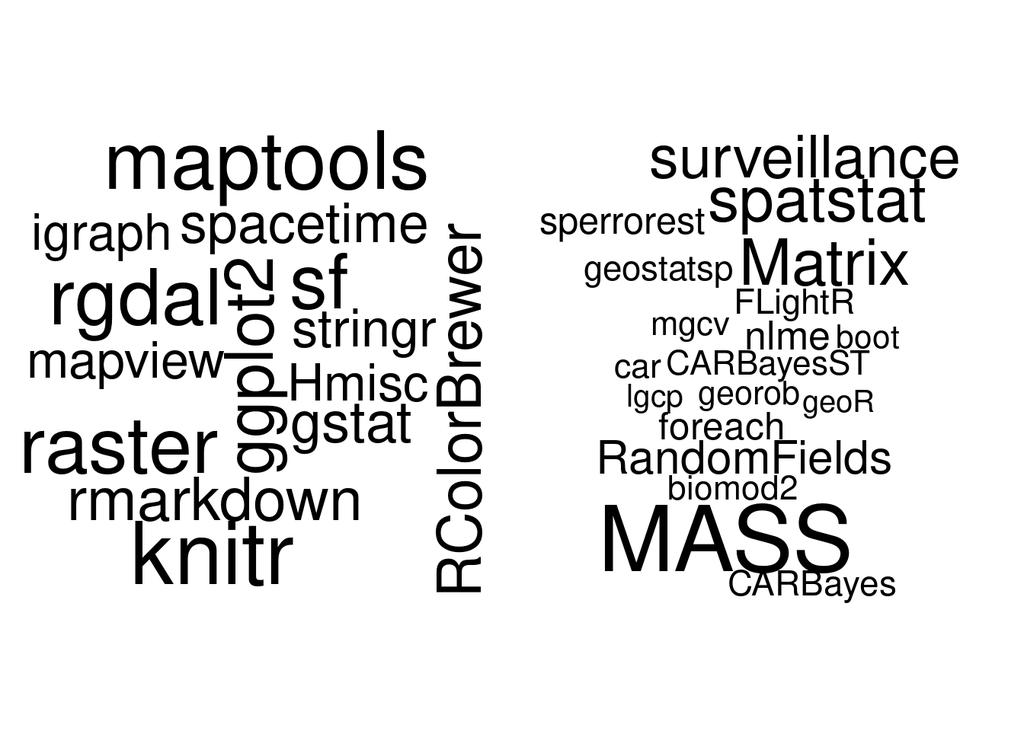

```r
library(RColorBrewer)
library(wordcloud)
opar <- par(mar=c(0,0,0,0)+0.1, mfrow=c(1,2))
for (i in 1:2) wordcloud(names(z[[i]]), freq=unname(z[[i]]), scale=rev(8*range(unname(z[[i]]))/max(unname(z[[4]]))))
```

```r
par(opar)
```

### CRAN third and fourth page rank clusters

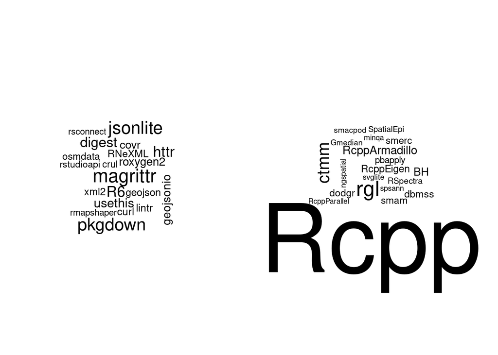

```r
opar <- par(mar=c(0,0,0,0)+0.1, mfrow=c(1,2))
for (i in 3:4) wordcloud(names(z[[i]]), freq=unname(z[[i]]), scale=rev(8*range(unname(z[[i]]))/max(unname(z[[4]]))))
```

```r
par(opar)
```

### Roundup: history

- R itself is very varied in the way that approaches have established niches through time
- `sp` classes date back to the same time as Bioconductor, which has a fairly definite S4 preference
- Communities develop and change over time, and continue to do so, with simultaneous differences in preferences
- so what comes after **tidyverse** and “data science”? Should we be preparing already?

### References

Abelson, Harold, and Gerald Jay Sussman. 1996. *Structure and Interpretation of Computer Programs*. Boston, MA: MIT Press.

Bao, Shuming, Luc Anselin, Doug Martin, and Diana Stralberg. 2000. “Seamless Integration of Spatial Statistics and GIS: The S-PLUS for ArcView and the S+Grassland Links.” *Journal of Geographical Systems* 2 (2): 287–306.

Becker, R.A., and J.M. Chambers. 1984. *S: An Interactive Environment for Data Analysis and Graphics*. Pacific Grove, CA, USA: Wadsworth & Brooks/Cole.

———. 1985. *Extending the S System*. Pacific Grove, CA, USA: Wadsworth & Brooks/Cole.

Becker, Richard A., John M. Chambers, and Allan R. Wilks. 1988. *The New S Language*. London: Chapman & Hall.

Bivand, Roger. 2000. “Using the R Statistical Data Analysis Language on GRASS 5.0 GIS Database Files.” *Computers & Geosciences* 26 (9): 1043–52. https://doi.org/https://doi.org/10.1016/S0098-3004(00)00057-1.

———. 2002. “Spatial Econometrics Functions in R: Classes and Methods.” *Journal of Geographical Systems* 4 (4): 405–21. https://doi.org/10.1007/s101090300096.

———. 2006. “Implementing Spatial Data Analysis Software Tools in R.” *Geographical Analysis* 38 (1): 23–40. https://doi.org/10.1111/j.0016-7363.2005.00672.x.

———. 2014. “Geocomputation and Open Source Software:Components and Software Stacks.” In *Geocomputation*, edited by Robert J. Abrahart and Linda M. See, 329–55. Boca Raton: CRC Press. http://hdl.handle.net/11250/163358.

Bivand, Roger, and Albrecht Gebhardt. 2000. “Implementing Functions for Spatial Statistical Analysis Using the R Language.” *Journal of Geographical Systems* 2 (3): 307–17. https://doi.org/10.1007/PL00011460.

Bivand, Roger, and Markus Neteler. 2000. *Open Source Geocomputation: Using the R Data Analysis Language Integrated with GRASS GIS and PostgreSQL Data Base Systems*. http://www.geocomputation.org/2000/GC009/Gc009.htm.

Chambers, John M. 1998. *Programming with Data*. New York: Springer.

———. 2016. *Extending R*. Boca Raton: Chapman & Hall.

Chambers, John M., and Trevor J. Hastie. 1992. *Statistical Models in S*. London: Chapman & Hall.

Evers, Kristian, and Thomas Knudsen. 2017. *Transformation Pipelines for Proj.4*. https://www.fig.net/resources/proceedings/fig_proceedings/fig2017/papers/iss6b/ISS6B_evers_knudsen_9156.pdf.

Gómez-Rubio, V., J. Ferrándiz-Ferragud, and A. López-Quílez. 2005. “Detecting Clusters of Disease with R.” *Journal of Geographical Systems* 7: 189–206.

Gómez-Rubio, V., and A. López-Quílez. 2005. “RArcInfo: Using GIS Data with R.” *Computers and Geosciences* 31: 1000–1006.

Ihaka, Ross, and Robert Gentleman. 1996. “R: A Language for Data Analysis and Graphics.” *Journal of Computational and Graphical Statistics* 5 (3): 299–314. https://doi.org/10.1080/10618600.1996.10474713.

Kernighan, Brian W., and Rob Pike. 1984. *The UNIX Programming Environment*. Englewood Cliffs, N. J.: Prentice-Hall.

———. 1999. *The Practice of Programming*. Reading, Mass.: Addison-Wesley.

Kernighan, Brian W., and P. J. Plauger. 1976. *Software Tools*. Reading, Mass.: Addison-Wesley.

Knudsen, Thomas, and Kristian Evers. 2017. *Transformation Pipelines for Proj.4*. https://meetingorganizer.copernicus.org/EGU2017/EGU2017-8050.pdf.

Kralidis, Athanasios Tom. 2008. “Geospatial Open Source and Open Standards Convergences.” In *Open Source Approaches in Spatial Data Handling*, edited by G. B. Hall and M. Leahy, 1–20. Berlin: Springer-Verlag.

McIhagga, David. 2008. “Communities of Practice and the Business of Open Sourceweb Mapping.” In *Open Source Approaches in Spatial Data Handling*, edited by G. B. Hall and M. Leahy, 49–64. Berlin: Springer-Verlag.

McIlroy, M. D. 1969. “’Mass produced’ software components.” In *Software Engineering*, edited by Peter Naur and Brian Randell, 79–87. Brussels: Conference on Software Engineering, NATO Science Committee; NATO Scientific Affairs Division.

Neteler, Markus, M. Hamish Bowman, Martin Landa, and Markus Metz. n.d. “GRASS GIS: A multi-purpose open source GIS.” *Environmental Modelling & Software* 31 (1): 124–30.

Neteler, M., D.E. Beaudette, P. Cavallini, L. Lami, and J. Cepicky. 2008. “GRASS GIS.” In *Open Source Approaches in Spatial Data Handling*, edited by G. B. Hall and M. Leahy, 171–99. Berlin: Springer-Verlag.

Pebesma, Edzer J. 2004. “Multivariable Geostatistics in S: The Gstat Package.” *Computers and Geosciences* 30: 683–91.

Pebesma, E. J., and R. S. Bivand. 2005. “Classes and Methods for Spatial Data in R.” *R News* 5 (2): 9–13.

Pebesma, E. J., and C. G. Wesseling. 1998. “Gstat, a Program for Geostatistical Modelling, Prediction and Simulation.” *Computers and Geosciences* 24: 17–31.

Rowlingson, B., and P. J. Diggle. 1993. “Splancs: Spatial Point Pattern Analysis Code in S-Plus.” *Computers and Geosciences* 19: 627–55.

Steiniger, Stefan, and Andrew J. S. Hunter. 2012. “Free and Open Source GIS Software for Building a Spatial Data Infrastructure.” In *Geospatial Free and Open Source Software in the 21st Century*, edited by Erwan Bocher and Markus Neteler, 247–61. Lecture Notes in Geoinformation and Cartography. Berlin Heidelberg: Springer.

Tierney, Luke. 1990. *LISP-STAT: An Object-Oriented Environment for Statistical Computing and Dynamic Graphics*. Wiley, New York, NY.

———. 1996. “Recent Developments and Future Directions in Lisp-Stat.” *Journal of Computational and Graphical Statistics* 5 (3): 250–62.

———. 2005. “Some Notes on the Past and Future of Lisp-Stat.” *Journal of Statistical Software* 13 (9): 1–15. https://doi.org/10.18637/jss.v013.i09.

Venables, William N., and Brian D. Ripley. 2000. *S Programming*. New York: Springer. http://www.stats.ox.ac.uk/pub/MASS3/Sprog/.

Wickham, Hadley. 2014. *Advanced R*. Boca Raton, FL: Chapman & Hall. http://adv-r.had.co.nz/.